# RISE Simulation v. 1.0

# Get Summary Information

```r
library(DT)
summary %>% mutate(temp = resource_mapped) %>%
  separate(resource_mapped,into = c("resource","scenario"),sep="_SC_") %>%
  mutate(scenario = ifelse(is.na(scenario),"global",scenario)) %>% select(aPSA_ID,preemptive,reactive,scenario,resource,N) %>%
  reshape2::dcast(aPSA_ID+preemptive+reactive+resource~scenario,value.var="N") %>%
  select(aPSA_ID,preemptive,reactive,resource,global, everything()) %>%
  unite(strategy,preemptive,reactive,sep="-") %>% group_by(strategy,resource) %>%
  summarise_at(.vars = c("global",as.character(scenario.names)),.funs=function(x) round(mean(x,na.rm=TRUE),1)) %>% arrange(resource,strategy,global) -> summary.dt
summary.dt %>% datatable(options = list(pageLength = 50),filter = 'top')
```

|  | strategy | resource | global | common_drug_rare_serious_ade | common_drug_common_sig_ade | rare_drug_common_serious_ade | rare_drug_rare_serious_ade |
| --- | --- | --- | --- | --- | --- | --- | --- |
| 1 | None-None | A |  | 1000.3 | 997 | 197.9 | 199.4 |
| 2 | None-Panel | A |  | 1000.3 | 997 | 197.9 | 199.4 |
| 3 | None-Single | A |  | 1000.4 | 997 | 197.9 | 199.4 |
| 4 | Panel-None | A |  | 1000.4 | 997 | 197.9 | 199.4 |
| 5 | None-None | A_c |  | 1000.3 | 997 | 197.9 | 199.4 |
| 6 | None-Panel | A_c |  | 1000.3 | 997 | 197.9 | 199.4 |
| 7 | None-Single | A_c |  | 1000.4 | 997 | 197.9 | 199.4 |
| 8 | Panel-None | A_c |  | 1000.4 | 997 | 197.9 | 199.4 |
| 9 | None-Panel | alt |  | 99.5 | 95.7 | 19.8 | 19 |
| 10 | None-Single | alt |  | 101.6 | 99.4 | 20.9 | 19.9 |

[output cut: 28 more lines]

# Estimate QALY and Costs

```r
source("../sub-files/costs_simple.R")
s1 <- seq(inputs$vN_PSA) %>% purrr::map_df(~cost.qaly(subset(results,preemptive=="None"& reactive=="None" & aPSA_ID==.x),inputs=inputs,psa_id=.x)) %>%
  rename(dQALY_None = dQALY , dCOST_None = dCOST)
s2 <- seq(inputs$vN_PSA) %>% purrr::map_df(~cost.qaly(subset(results,preemptive=="Panel"& reactive=="None" & aPSA_ID==.x),inputs=inputs,psa_id=.x)) %>%
  rename(dQALY_Panel_None = dQALY , dCOST_Panel_None = dCOST)
s3 <- seq(inputs$vN_PSA) %>% purrr::map_df(~cost.qaly(subset(results,preemptive=="None"& reactive=="Panel" & aPSA_ID==.x),inputs=inputs,psa_id=.x)) %>% rename(dQALY_None_Panel = dQALY , dCOST_None_Panel = dCOST)
s4 <- seq(inputs$vN_PSA) %>% purrr::map_df(~cost.qaly(subset(results,preemptive=="None"& reactive=="Single" & aPSA_ID==.x),inputs=inputs,psa_id=.x)) %>% rename(dQALY_None_Single = dQALY , dCOST_None_Single = dCOST)
Sim <- cbind(s1,s2,s3,s4,drawn.parameter.values$global)
```

```r
setwd("../")
```

```
The working directory was changed to /Users/johngraves/Dropbox/Projects/RISE/rise-simulation inside a notebook chunk. The working directory will be reset when the chunk is finished running. Use the knitr root.dir option in the setup chunk to change the the working directory for notebook chunks.
```

```r
source("./sub-files/metamodeling-functions.R")
Strategies <-
  c("None",
    "Panel_None",
    "None_Panel",
    "None_Single")
#Determine the number of strategies
ndep <- length(Strategies)
#Create vector of variable names
Names <- colnames(Sim)
Parms <- Sim[, -grep("QALY|COST", colnames(Sim))] %>% dplyr::select(dplyr::contains("Probability"))
#Get parameter names
paramNames <- colnames(Parms)
indep <- ncol(Parms)
Outcomes <- Sim[, grep("QALY|COST", colnames(Sim))]
lambda <- 50000
Sim <- Sim %>% mutate(NHB_None = dQALY_None - dCOST_None / lambda,
                      NHB_Panel_None = dQALY_Panel_None - dCOST_Panel_None / lambda,
                      NHB_None_Panel = dQALY_None_Panel - dCOST_None_Panel / lambda,
                      NHB_None_Single = dQALY_None_Single - dCOST_None_Single / lambda) %>%
  mutate(Iteration = row_number())
NHB <- Sim %>% dplyr::select(dplyr::contains("NHB"))
```

# Linear Metamodel

The first example for linear metamodel will be on the outcomes (i.e., effectivenes, costs and NHB). We will run two versions of the metamodel based on how we incorporate the simulation parameters (**Important**: In the metamodel the simluation parameters will act as the independent variables):

1. With unstandardized values of the simulation paramaters $x_j$ and
2. With standardized values of the simulation paramaters $z_j$, defined as
   $$z_j = \frac{x_j-\bar{x_j}}{\sigma_j}$$
   where $\bar{x_j}$ and $\sigma_j$ are the mean and standard deviation of $x_j$, respectively. We can standardized the simulation parameters within the linear regression specification in `R` using the command `scale`.

```r
require(tidyr)
require(broom)
# Unscaled #
Cost.Fit <- c("None","Panel_None","None_Panel","None_Single") %>% purrr::map(~broom::tidy(lm(
  as.formula(paste0("dCOST_",.x,"~",paste0(colnames(Parms),collapse="+")))
  ,data=Sim)))
Effectiveness.Fit <- c("None","Panel_None","None_Panel","None_Single") %>% purrr::map(~tidy(lm(
  as.formula(paste0("dQALY_",.x,"~",paste0(colnames(Parms),collapse="+")))
  ,data=Sim)))
NHB.Fit <- c("None","Panel_None","None_Panel","None_Single") %>% purrr::map(~tidy(lm(
  as.formula(paste0("NHB_",.x,"~",paste0(colnames(Parms),collapse="+")))
  ,data=Sim)))
# Scaled
Cost.Scaled.Fit <- c("None","Panel_None","None_Panel","None_Single") %>% purrr::map(~tidy(lm(
  as.formula(paste0("dCOST_",.x,"~",paste0(paste0("scale(",colnames(Parms),")"),collapse="+")))
  ,data=Sim)))
Effectiveness.Scaled.Fit <- c("None","Panel_None","None_Panel","None_Single") %>% purrr::map(~tidy(lm(
  as.formula(paste0("dQALY_",.x,"~",paste0(paste0("scale(",colnames(Parms),")"),collapse="+")))
  ,data=Sim)))
NHB.Scaled.Fit <- c("None","Panel_None","None_Panel","None_Single") %>% purrr::map(~tidy(lm(
  as.formula(paste0("NHB_",.x,"~",paste0(paste0("scale(",colnames(Parms),")"),collapse="+")))
  ,data=Sim)))
```

## One Way Sensitivity Analysis

```r
Sim.long<- melt(Sim, id.vars=c("Iteration",grep("Probability",Names,value=TRUE)),measure.vars=c("NHB_None","NHB_Panel_None","NHB_None_Panel","NHB_None_Single"))
```

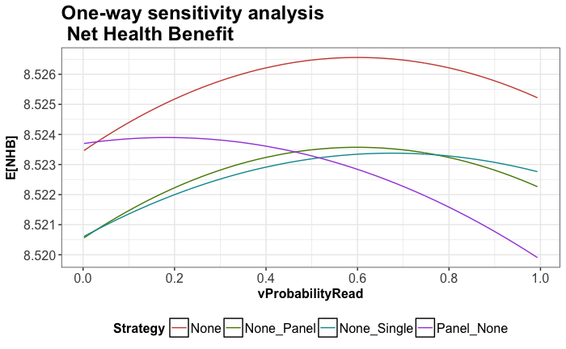

## Threshold Analysis

```
duplicated levels in factors are deprecated
```

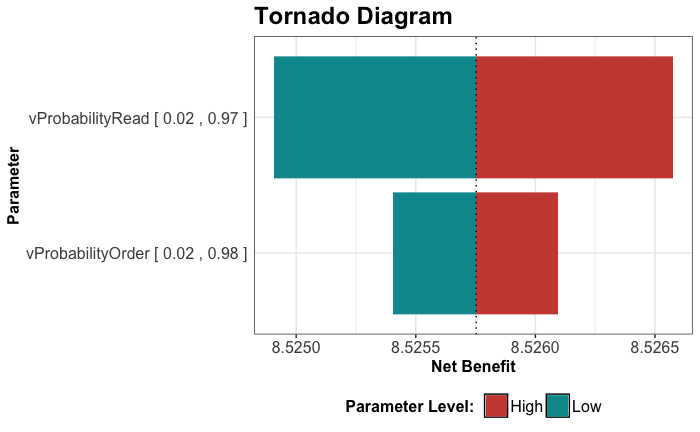

```r
# Need to fit a model over all the strategies
NHB.Scaled.Fit <- Strategies %>% purrr::map(~tidy(lm(
  as.formula(paste0("NHB_",.x,"~",paste0(paste0("scale(",colnames(Parms),")"),collapse="+")))
  ,data=Sim)))
names(NHB.Scaled.Fit) = Strategies
Strategy.Combinations <- t(combn(Strategies,2))  %>% data.frame() %>% filter(as.character(X1)!=as.character(X2)) %>%
  mutate_all(.funs=as.character)
delta <- map2(.x=as.character(Strategy.Combinations$X1),.y=as.character(Strategy.Combinations$X2),.f=~NHB.Scaled.Fit[[.x]]$estimate/NHB.Scaled.Fit[[.y]]$estimate)
names(delta) = paste0(as.character(Strategy.Combinations$X1),"_vs_",as.character(Strategy.Combinations$X2))
delta <- delta %>% bind_rows()
zeta <- delta %>% purrr::map(~.x[1]/.x[-1]) %>% bind_rows()
TornadoOpt(Parms,NHB)
```

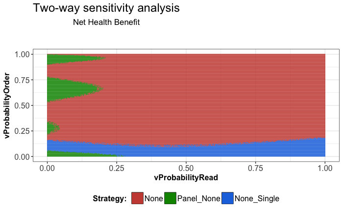

```r
parm1<-'vProbabilityRead'
parm2<-'vProbabilityOrder'
range1<-c(0,1)
range2<-c(0,1)
TwoWaySA(Strategies,Parms,Outcomes=NHB,parm1,parm2,range1,range2)
```